# Visualización de datos con `{ggplot2}`

# ¿Por dónde empezamos?

## Cargamos el paquete

```r
library(ggplot2)
```

o…

```r
library(tidyverse)
```

## Gráfico en clave de capas

3 Capas son las indispensables al pensar nuestro gráfico:

## Gráfico en clave de capas

- Los **datos** (argumento: `data =`):
  - El dataframe que sirve de insumo

## Gráfico en clave de capas

- Los **datos** (argumento: `data =`):
  - El dataframe que sirve de insumo
- Las **aesthetics** (función `aes()`:
  - Defino el vínculo entre los datos y las propiedades visuales (ejes x e y, por ej.)

## Gráfico en clave de capas

- Los **datos** (argumento: `data =`):
  - El dataframe que sirve de insumo
- Las **aesthetics** (función `aes()`:
  - Defino el vínculo entre los datos y las propiedades visuales (ejes x e y, por ej.)
- Las **geometrías** (función `geom_*()`:
  - La geometría con la que se representan los datos

## Gráfico en clave de capas

- Pregunta-problema: Quiero representar la cantidad de **habitaciones** por **tipo de alojamiento**, para el **año 2022**

Preparo los datos:

```r
library(tidyverse)
df_puna <- read_csv("data/puna_base_agregada.csv")

df_habitaciones_2022 <- df_puna |>
  filter(indice_tiempo == 2022) |>
  group_by(tipo) |>
  summarise(habitaciones_n = sum(habitaciones, na.rm = T))
```

## Gráfico en clave de capas

- Así queda nuestra tabla:

```r
df_habitaciones_2022
```

```
# A tibble: 3 × 2
  tipo             habitaciones_n
  <chr>                     <dbl>
1 Hoteleros                185351
2 Otros colectivos           2810
3 Parahoteleros             58490
```

## Gráfico en clave de capas

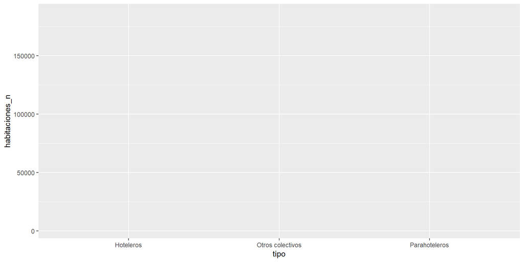

```r
ggplot(data = df_habitaciones_2022,
       aes(x = tipo, y = habitaciones_n))
```

## Gráfico en clave de capas

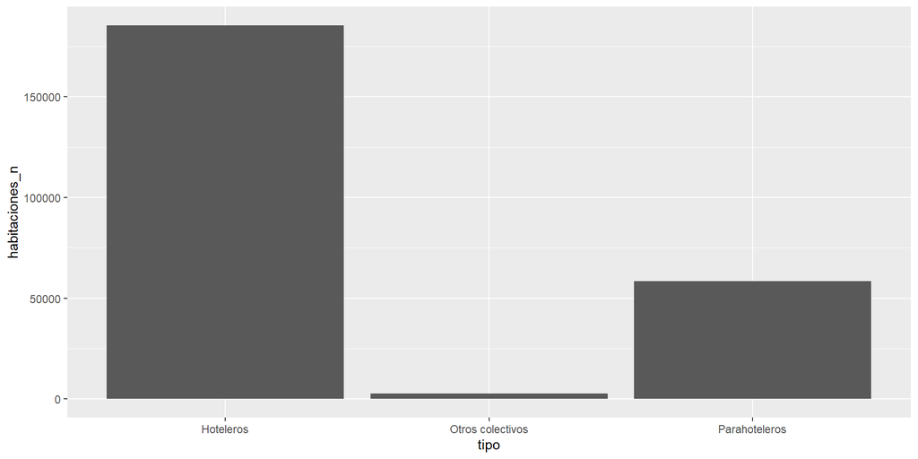

```r
ggplot(data = df_habitaciones_2022,
       aes(x = tipo, y = habitaciones_n)) +
  geom_col()
```

# Chapa y pintura

## Chapa y pintura - Relleno

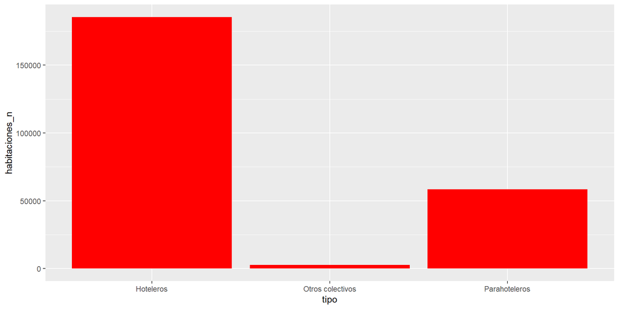

```r
ggplot(data = df_habitaciones_2022,
       aes(x = tipo, y = habitaciones_n)) +
  geom_col(fill = "red")
```

## Chapa y pintura - Relleno

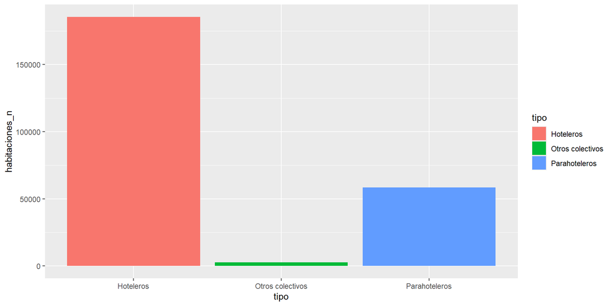

```r
ggplot(data = df_habitaciones_2022,
       aes(x = tipo, y = habitaciones_n)) +
  geom_col(aes(fill = tipo))
```

## Chapa y pintura - Contorno

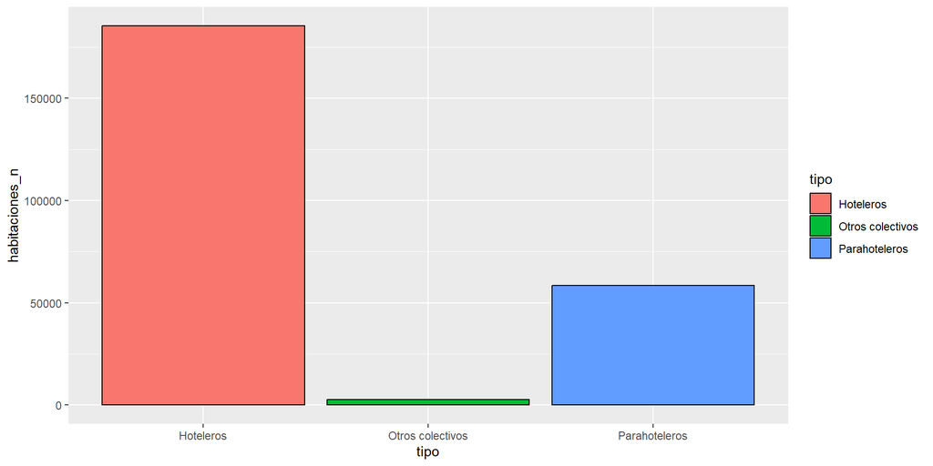

```r
ggplot(data = df_habitaciones_2022,
       aes(x = tipo, y = habitaciones_n)) +
  geom_col(aes(fill = tipo),
           color = "black")
```

## Chapa y pintura - Referencias

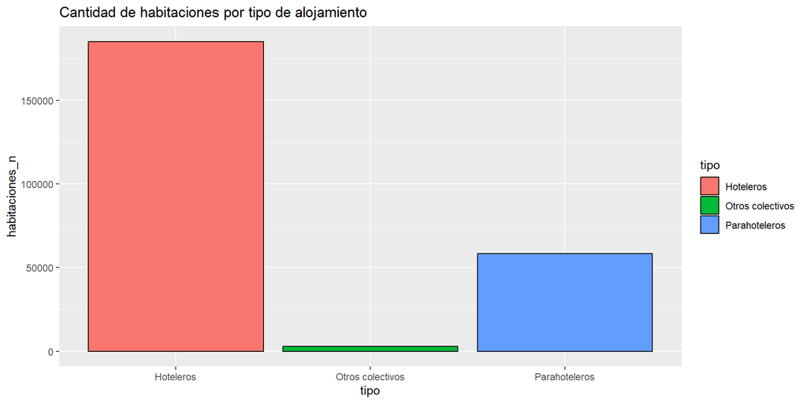

```r
ggplot(data = df_habitaciones_2022,
       aes(x = tipo, y = habitaciones_n)) +
  geom_col(aes(fill = tipo),
           color = "black") +
  labs(title = "Cantidad de habitaciones por tipo de alojamiento")
```

## Chapa y pintura - Referencias

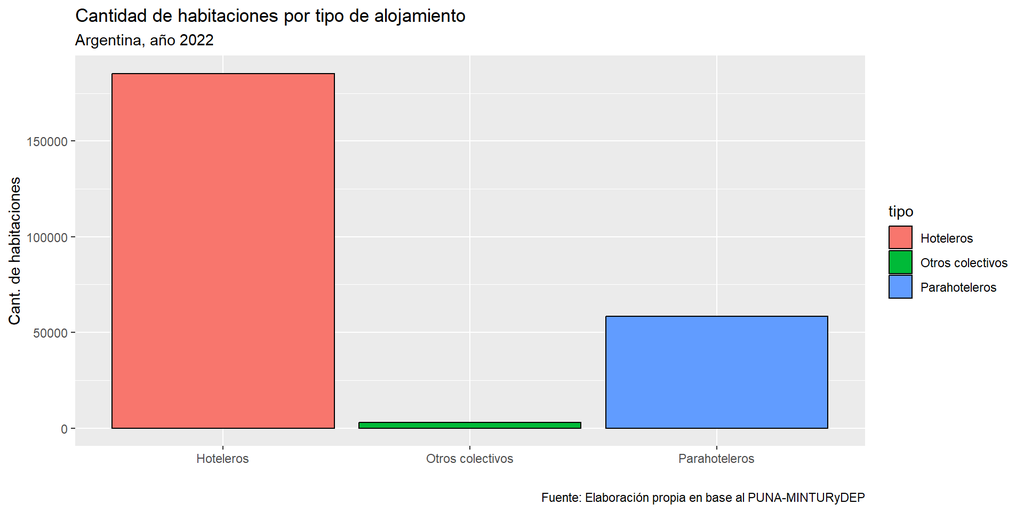

```r
ggplot(data = df_habitaciones_2022,
       aes(x = tipo, y = habitaciones_n)) +
  geom_col(aes(fill = tipo),
           color = "black") +
  labs(title = "Cantidad de habitaciones por tipo de alojamiento",
       subtitle = "Argentina, año 2022",
       x = "",
       y = "Cant. de habitaciones",
       caption = "Fuente: Elaboración propia en base al PUNA-MINTURyDEP")
```

## Chapa y pintura - theme

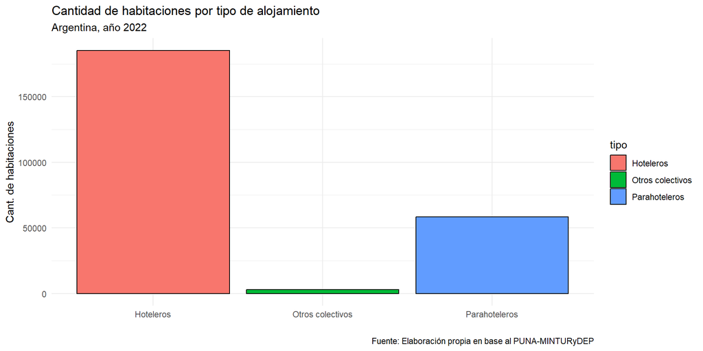

```r
ggplot(data = df_habitaciones_2022,
       aes(x = tipo, y = habitaciones_n)) +
  geom_col(aes(fill = tipo),
           color = "black") +
  labs(title = "Cantidad de habitaciones por tipo de alojamiento",
       subtitle = "Argentina, año 2022",
       x = "",
       y = "Cant. de habitaciones",
       caption = "Fuente: Elaboración propia en base al PUNA-MINTURyDEP") +
  theme_minimal()
```

## Chapa y pintura - theme

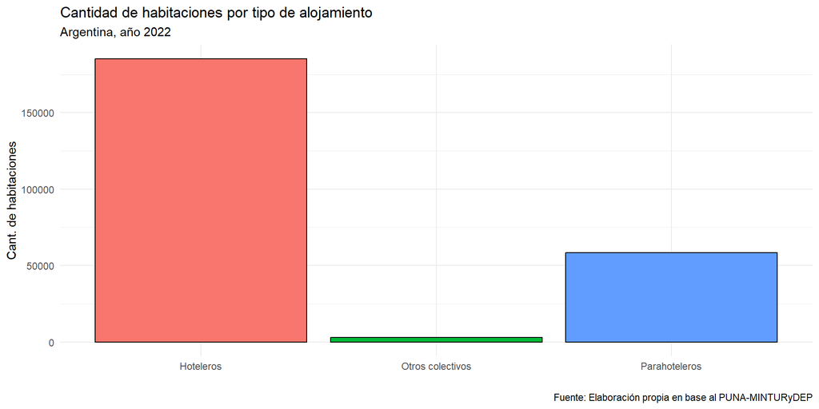

```r
ggplot(data = df_habitaciones_2022,
       aes(x = tipo, y = habitaciones_n)) +
  geom_col(aes(fill = tipo),
           color = "black") +
  labs(title = "Cantidad de habitaciones por tipo de alojamiento",
       subtitle = "Argentina, año 2022",
       x = "",
       y = "Cant. de habitaciones",
       caption = "Fuente: Elaboración propia en base al PUNA-MINTURyDEP") +
  theme_minimal() +
  theme(legend.position = "none")
```

[figure not shown]

[🔗 Introducción al Procesamiento de Datos con R](https://pablotis.github.io/intro-r-quarto/)